# GCC Sovereign Wealth Funds and the AI-Capital Pivot, 2023-2026

How Gulf sovereign capital re-tooled to climb the AI value chain, and whether the bet pays

Author

Gen

Published

May 28, 2026

Abstract

Between 2023 and 2026 the sovereign wealth funds of the Gulf Cooperation Council moved from passive global investors to founders and operators of artificial-intelligence infrastructure. They created national champions, contracted gigawatts of compute, secured advanced-chip allocations, and bought minority stakes across the frontier-model labs. In 2025 alone, sovereign investors deployed about $66 billion into AI and digitalization, with Middle East funds leading the world.

This report maps that pivot and asks whether it pays. A coordinated institutional stack, Humain in Saudi Arabia, MGX in Abu Dhabi, and the Qatar Investment Authority’s direct book, channels capital up an AI value chain from energy through compute, chips, models, and applications. Yet the ascent has a ceiling: the Gulf can own the bottom of the stack, but the chip and frontier-model layers are gated by terms set outside the region, and the financial case rests more on strategic-option logic than on demonstrated returns.

The verdict is conditional. The pivot is defensible as strategy and diversification but unproven as investment, and its payoff turns on five variables, chief among them chip-access stability and the oil price, that the Gulf only partly controls.

**Keywords**: GCC sovereign wealth funds | Public Investment Fund | MGX | AI infrastructure | data centers | Vision 2030 | compute value chain

# 1 Introduction: the Gulf’s 24-month pivot

The Gulf turned its sovereign capital toward artificial intelligence faster than any region on earth. In the space of roughly two years, the sovereign wealth funds of Saudi Arabia, the United Arab Emirates, and Qatar went from buying minority stakes in Western technology companies to founding national AI champions, contracting hundreds of megawatts of computing capacity, and anchoring some of the largest infrastructure deals ever recorded. The shift is not a routine portfolio rotation. It is a deliberate attempt to convert three things the Gulf has in abundance, hydrocarbon rents, cheap energy, and patient capital, into a durable position in what the funds themselves describe as the defining technology of the century.

The ambition is openly stated. Saudi Arabia’s new state AI company set out to become the world’s third-largest AI provider behind the United States and China; the UAE, which published a national AI strategy aiming for leadership by 2031, unveiled a five-gigawatt data-center campus described as the largest such project outside the United States (CNBC 2025b; DataCenterDynamics 2025). These are not the cautious words of a financial investor diversifying a portfolio. They are the language of industrial policy, pursued with a sovereign balance sheet.

Figure 1: From rent collectors to compute builders: the Gulf’s sovereign AI pivot compressed into roughly 24 months

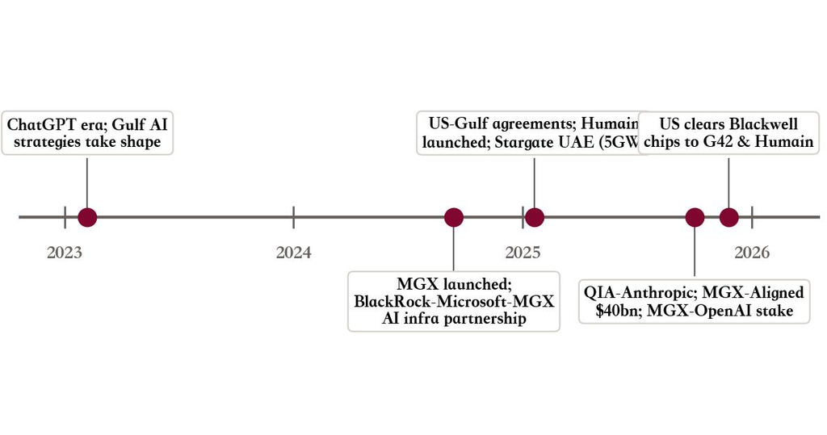

*Source: Global SWF; Nvidia newsroom; Axios; CNBC; company announcements | Note: Selected milestones, 2023-2025; dates approximate to the announcement month.*

## 1.1 Argument map and the limits of the claim

This report builds its argument in five moves. The first is anatomy: how much capital the Gulf deployed, how fast, through what institutions, and against what fiscal backdrop. The second is the value chain: what the funds are actually buying, layer by layer, from energy at the bottom to applications at the top. The third is the binding constraint: why access to advanced chips, a regulatory variable set outside the region, caps how far sovereign capital can climb. The fourth is the verdict, weighing the strategic case against the financial risks. The fifth is the outlook, the variables that will decide whether the bet pays. The structure is deliberate: the descriptive chapters earn the right to the judgment in the later ones.

Two limits are worth stating at the outset. This report does not build an original financial model, and it does not estimate fund-level returns on AI, because the funds do not disclose them; where a return is discussed, it is as a qualitative judgment, not a measured figure. It also distinguishes throughout between announced pledges, which are plentiful and headline-grabbing, and deployed capital, which is a smaller, slower, and harder number to pin down. Where the evidence supports only a directional reading, the text says so rather than dressing inference as fact. Many of the figures, particularly fund assets and single-year deployment totals, come from data aggregators and press reporting whose calipers differ; those differences are flagged rather than smoothed over.

# 2 Anatomy of the pivot: how much, how fast, from where

Figure 2 ranks the six. The concentration matters for what follows. A handful of institutions, each with a balance sheet rivaling the largest private asset managers, can commit to a new asset class in a single board cycle, without the fundraising, consensus-building, or redemption pressure that constrains private capital. When the PIF decides to stand up a national AI company, it does not need to raise a fund first.

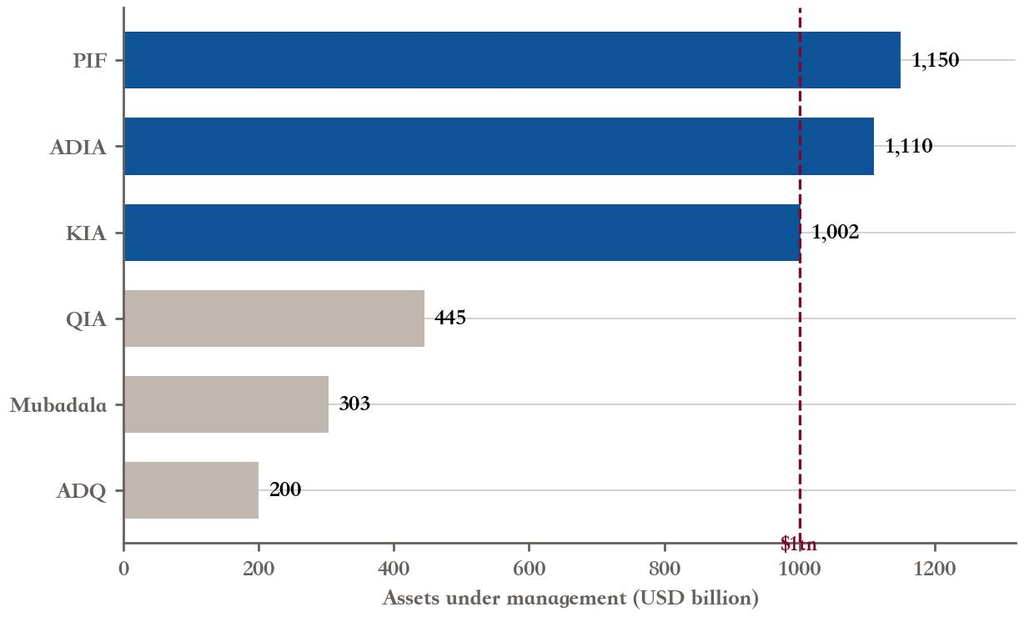

*Source: Global SWF rankings, July 2025 (via Gulf Business, Zawya) | Note: PIF = Public Investment Fund; ADIA = Abu Dhabi Investment Authority; KIA = Kuwait Investment Authority; QIA = Qatar Investment Authority.*

The funds are not interchangeable, and their differences shape the pivot. ADIA and the KIA are the oldest and most conservative, long-horizon managers of external surpluses with globally diversified, largely passive books. Mubadala and ADQ are development-minded and far more active, used by Abu Dhabi as instruments of economic strategy. The PIF sits at the activist end of the spectrum, with an explicit domestic mandate to build new industries inside the kingdom under Vision 2030. That spread explains why the AI pivot has flowed through the activist vehicles, the PIF, Mubadala, ADQ, and the QIA, rather than the passive giants: building national champions is a development mission, not a reserve-management one.

The Public Investment Fund illustrates the trajectory most vividly. Its assets rose roughly sevenfold in a decade, from an estimated $160 billion in 2015 to about $1.15 trillion in 2025, as the Saudi state transferred reserves and Aramco stakes onto its balance sheet and recycled them into domestic giga-projects and global investments (Global SWF 2025). Figure 3 shows the climb. The 2024 and 2025 endpoints are firm; the intermediate years are estimates drawn from aggregators and disclosures, and are shown as such. The PIF raised its 2030 assets target to about $2.67 trillion in April 2025, up from an earlier goal near $2 trillion, which would make it among the largest pools of sovereign capital anywhere (The National 2025); whether it reaches that figure depends heavily on the oil-and-fiscal backdrop examined later in this chapter.

Figure 3: PIF assets rose roughly sevenfold in a decade, to about $1.15tn

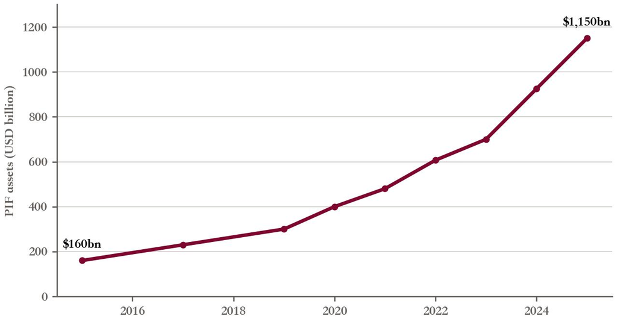

*Source: Global SWF, SWFI and PIF disclosures; intermediate years estimated | Note: 2024-2025 endpoints firm; 2015-2023 are estimates from aggregator and press figures.*

## 2.2 A year that put $66 billion of sovereign capital into AI, Gulf-led

The flows into AI specifically are recent and concentrated, which is the second defining feature of the pivot. Global SWF estimates that sovereign-owned investors deployed about $66 billion into AI and digitalization in 2025, the year the category shifted from an opportunistic allocation to a stated strategic priority (Global SWF 2026). The Middle East led the world. Mubadala committed $12.9 billion, the Kuwait Investment Authority $6 billion, and the Qatar Investment Authority $4 billion, the three largest single-fund commitments globally that year.

Figure 4 shows the leaders. Two caveats travel with the figure. First, the caliper is AI and digitalization together, which is broader than pure AI and sweeps in adjacent technology spending; comparisons that treat it as pure-AI deployment will overstate the AI share. Second, it measures a single year’s flow rather than cumulative exposure, so it captures the pace of 2025 rather than the total stock of Gulf AI assets, which is larger and harder to bound. Both points recur whenever sovereign AI figures are compared across sources, because aggregators and the funds themselves define the category differently.

Figure 4: Mubadala led Middle East funds with $12.9bn of AI and digital deployment in 2025

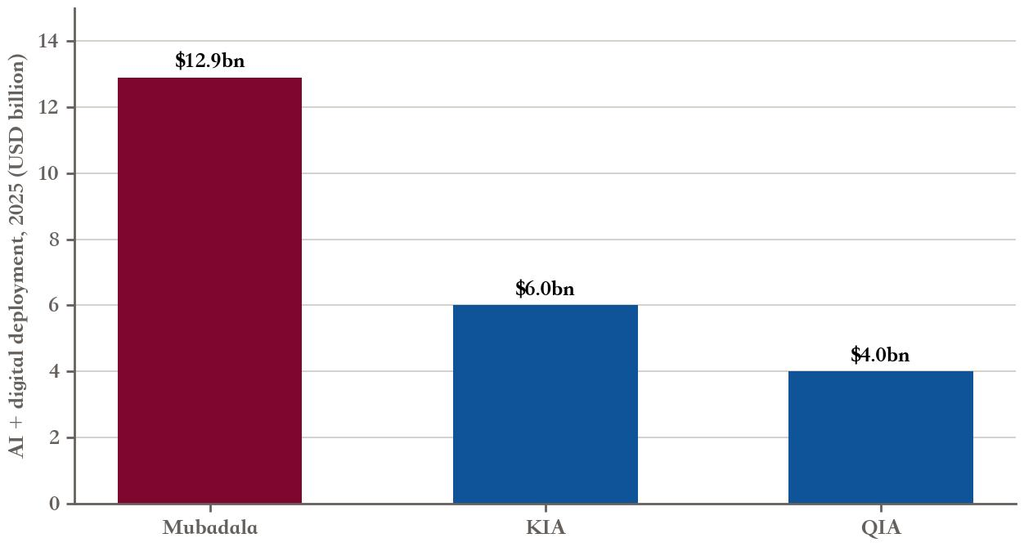

*Source: Global SWF 2026 Annual Report (via Bloomberg, Gulf News) | Note: Sovereign investors globally deployed about $66bn into AI and digitalization in 2025; figures cover the three leading Middle East funds.*

The speed of the tilt is as notable as its size. Industry trackers reported that Middle East sovereign capital flowing into AI companies rose several-fold over the preceding year, with the bulk of the activity concentrated after 2024 as the funds stood up dedicated vehicles and signed framework agreements (Global SWF 2026). This is not a allocation that drifted up gradually with rising valuations; it stepped up sharply once the institutional machinery, examined in the next chapter, was in place. The funds did not wait to see how AI played out before committing. They moved while the technology, and its economics, were still being established, which is precisely what makes the bet an option on the future rather than a position in a proven business.

## 2.3 Why now: thinner fiscal cushions raise the stakes, not lower them

The pivot is happening just as the Gulf’s traditional cushion, oil revenue, thins, and the timing is not a coincidence. Saudi Arabia swung from a fiscal surplus of about 2.2 percent of GDP in 2022 to a deficit of 2.5 percent in 2024, with the IMF projecting the deficit widening toward 4 percent in 2025 as oil prices softened and giga-project spending continued (IMF 2025). The current account told the same story, moving from a surplus above 12 percent of GDP in 2022 to a small deficit by 2024. Figure 5 shows the fiscal path, including the IMF’s negative oil-price stress scenario, under which the overall deficit would reach 6.7 percent of GDP in 2025 and exceed 10 percent in 2026.

Figure 5: Saudi Arabia swung from a 2022 surplus to persistent deficits; an oil shock would push it past -10%

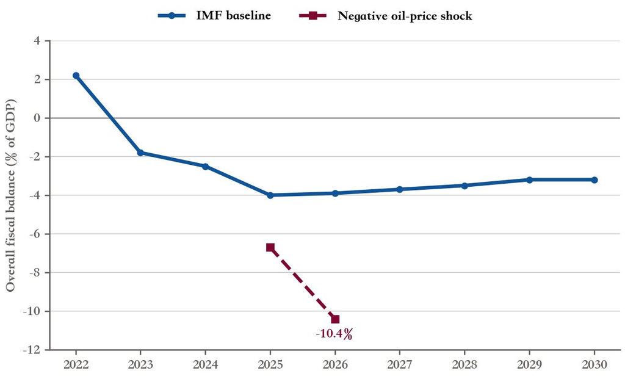

*Source: IMF Saudi Arabia 2025 Article IV, Table 1 and Annex VII | Note: Net lending/borrowing of central government; shock scenario from the IMF’s negative oil-price stress test.*

The pressure is structural rather than cyclical, which is what makes it relevant to a multi-decade strategy. The IMF projects Saudi oil export prices easing to about $70 a barrel in 2025 and holding near $67 to $68 through 2030, comfortably below the kingdom’s fiscal breakeven (IMF 2025). Estimates of that breakeven cluster around $94 a barrel on the government budget, rising to roughly $101 to $111 once the PIF’s domestic spending is included, the difference reflecting whether the giga-project outlays funded through the PIF are counted (Emirates NBD Research 2025). Figure 6 sets the projected oil price against that breakeven band. The persistent gap between the two lines is the structural deficit that diversification is ultimately meant to close.

Figure 6: Projected oil prices sit well below Saudi Arabia’s fiscal breakeven through 2030

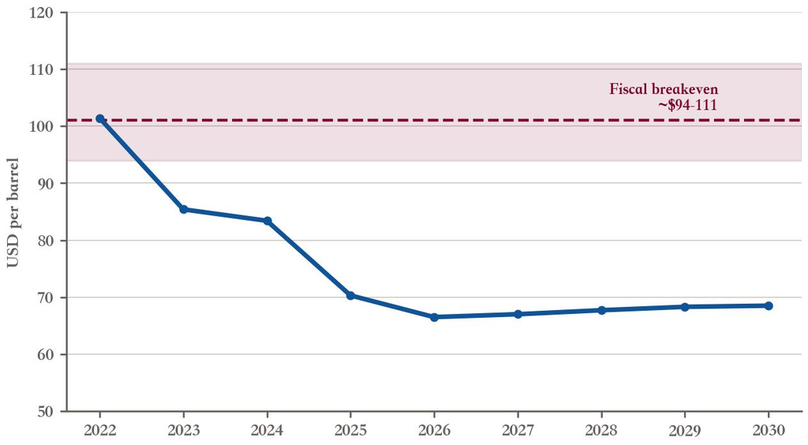

*Source: IMF Saudi Arabia 2025 Article IV, Table 1 (oil price); Emirates NBD, Bloomberg Economics (breakeven) | Note: Breakeven band ~$94/bbl on the budget, ~$111 including PIF domestic spending; Emirates NBD estimates ~$101 for 2025.*

A softer oil price raises the urgency of diversification rather than relieving it, and this is the counterintuitive logic at the heart of the pivot’s timing. If oil revenue looked secure for decades, the Gulf could afford to diversify slowly. Because the long-run revenue base looks weaker, the case for spending heavily today to build a different one grows stronger, even though the same soft oil price tightens the budget that funds the spending. The IMF’s own read is that diversification has genuine momentum, with non-oil real GDP growing 4.5 percent in 2024, but that the fiscal path now depends on either an oil-price recovery or sustained non-oil revenue mobilization (IMF 2025). AI is the newest, and by far the most capital-intensive, expression of the diversification imperative.

## 2.4 The funding logic: oil still pays the bills, and the PIF is the engine

For now, oil still funds the transition, which is the uncomfortable arithmetic beneath the AI ambition. Saudi central-government oil revenue was about SAR 757 billion in 2024 against SAR 502 billion of non-oil revenue, and on IMF projections the two lines nearly converge by 2030, at roughly SAR 690 billion and SAR 688 billion respectively (IMF 2025). Figure 7 shows the convergence. It is the diversification story compressed into a single chart: non-oil revenue is catching up steadily, but oil is still doing the heavier lifting throughout the very period in which the AI bets are being placed. The new economy is being financed, in large part, by the old one.

Figure 7: Non-oil revenue nearly catches oil by 2030, but oil still funds the diversification push today

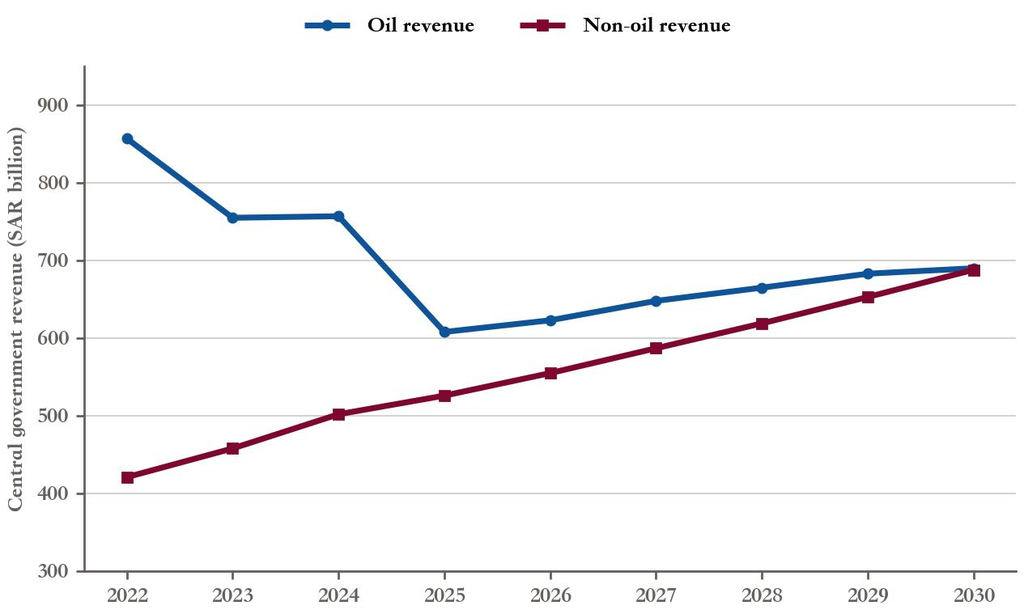

*Source: IMF Saudi Arabia 2025 Article IV, Table 2 (budgetary central government operations) | Note: IMF staff projections from 2025 onward; figures reconcile to total central government revenue.*

The PIF is the engine of the domestic build-out. The IMF expects it to inject at least $40 billion a year into the Saudi economy as it funds giga-projects such as NEOM and, increasingly, AI infrastructure (IMF 2025). Crucially, much of this spending runs through the PIF’s own balance sheet rather than the government budget, which is why headline budget-breakeven figures understate the true oil price the kingdom needs; the breakeven including PIF spending is materially higher. The arrangement gives the state flexibility, but it also means the AI build is exposed to the PIF’s own funding capacity, which depends on asset performance, dividends from Aramco, and the fund’s ability to borrow.

Part of that funding is debt. Saudi central-government gross debt is projected to rise from 21 percent of GDP in 2022 to about 41 percent by 2030, and the PIF itself has become a regular issuer of bonds and syndicated loans (IMF 2025). Figure 8 shows the climb. By global standards the debt level remains low, and the kingdom retains substantial buffers, so this is not a solvency concern. But the direction is unambiguous: the Gulf is part-funding its future with borrowing, against a softer oil outlook, which raises the stakes on the returns the new investments eventually generate. Debt taken on at low rates to build assets that do not earn is a different proposition from debt that funds productive capacity, and which of the two the AI build turns out to be is the open question this report returns to.

Figure 8: Saudi Arabia is part-funding the pivot with debt: gross debt nearly doubles to 40.6% of GDP by 2030

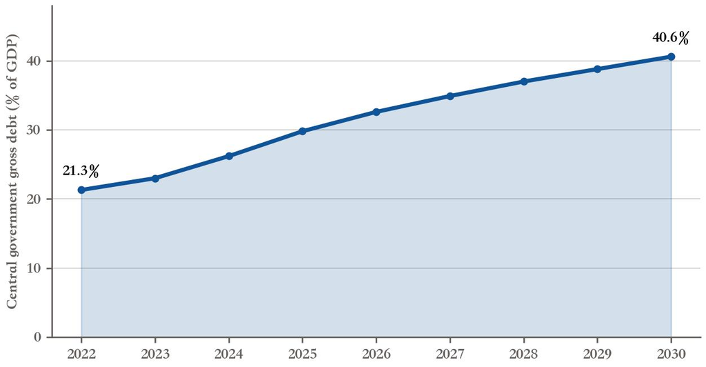

*Source: IMF Saudi Arabia 2025 Article IV, Table 2 (memorandum items) | Note: IMF staff projections; debt remains low by global standards but is rising to finance deficits and giga-projects.*

# 3 The vehicles: a new sovereign AI institutional stack

## 3.1 Each capital built a purpose-made AI champion

The pivot is institutional, not merely financial, and this is what distinguishes it from a portfolio tilt. Rather than route AI investments through their existing general portfolios, each Gulf capital built dedicated vehicles with their own mandates, leadership, and partnership networks. Figure 9 maps the stack. In Saudi Arabia, the PIF created Humain as a full-stack AI champion alongside a separate AI-focused investment fund; in Abu Dhabi, Mubadala and the AI operator G42 created MGX as a global AI-infrastructure investor, complementing G42’s role as the emirate’s operating arm; in Qatar, the QIA runs a more direct book of stakes and joint ventures rather than a single branded vehicle. The common feature is coordination. These are instruments of national strategy, designed to concentrate decision-making and present a single counterparty to global partners, rather than a scatter of opportunistic deals.

Figure 9: Each Gulf capital built a purpose-made AI vehicle: Humain, MGX, and QIA’s direct book

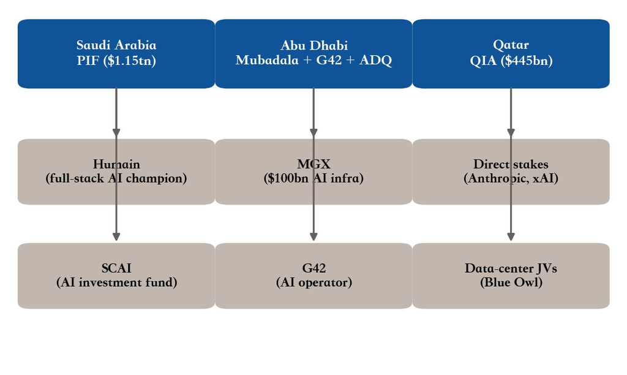

*Source: PIF, Mubadala, G42, MGX and QIA disclosures | Note: A coordinated institutional stack rather than scattered deals; AUM figures per Global SWF, July 2025.*

## 3.2 Saudi Arabia: Humain as a full-stack national champion

Humain is the most ambitious of the vehicles, and the clearest statement of the full-stack strategy. Launched by the PIF in May 2025 under chief executive Tareq Amin, it set out to control the entire AI value chain inside the kingdom, from data centers and chips through models to applications, with the explicit goal of becoming the world’s third-largest AI provider behind the United States and China (CNBC 2025b). The framing is telling: not a national user of AI, but a national provider, selling compute and services to a global market.

Within months Humain had signed a remarkable string of capacity agreements. It partnered with Nvidia for an initial 500-megawatt build powered by 18,000 of the company’s most advanced chips, with several hundred thousand more to follow over five years; struck a one-gigawatt joint venture with AMD and Cisco; agreed a 500-megawatt project with xAI; established a $5 billion AI Zone with AWS; deployed Groq chips for inference; and signed a roughly $3 billion partnership with the data-center operator AirTrunk, alongside a $1.2 billion financing package for 250 megawatts of capacity (NVIDIA 2025; Semafor 2025; DataCenterDynamics 2026). The breadth of partners, spanning Nvidia, AMD, Qualcomm, Cisco, AWS, xAI, and Groq, is itself the strategy: Humain is assembling a vendor ecosystem rather than betting on a single supplier.

Figure 10 sizes the capacity-denominated deals, which total roughly two gigawatts contracted in the vehicle’s first months. Demand has run ahead of supply in a way that supports the commercial thesis: by August 2025 Humain reported it had already sold out its planned capacity, with only a small fraction of customers domestic (Semafor 2025). That detail matters. A build aimed largely at export, at global customers renting Saudi compute, is a more plausible diversification play than one sized to internal demand alone, because it generates foreign revenue rather than simply substituting for imports. It also exposes Humain to global compute pricing and the risk of a capacity glut, themes taken up in the verdict.

Figure 10: Humain contracted roughly 2.0GW of compute within months of its May-2025 launch

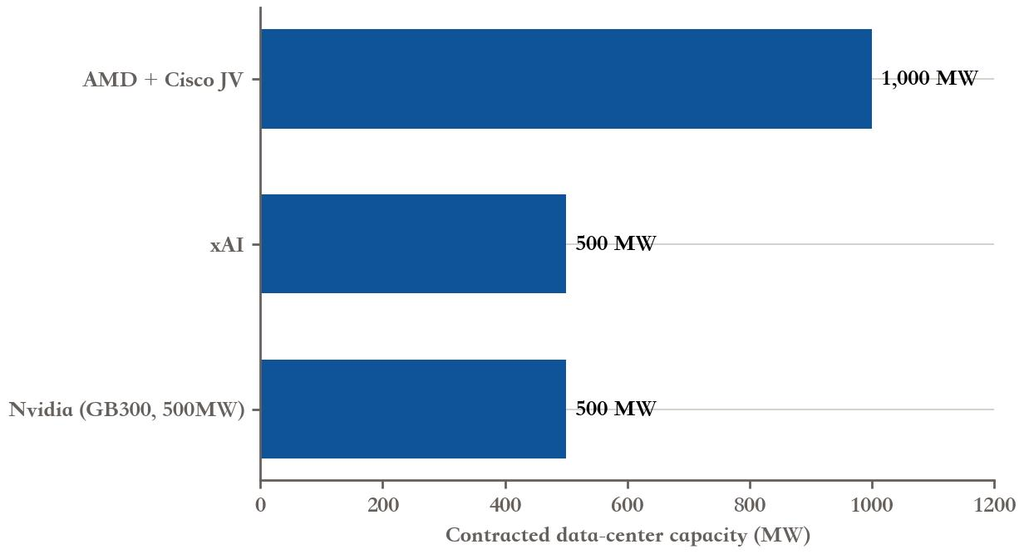

*Source: Nvidia newsroom; CNBC; DataCenterDynamics; Semafor | Note: Capacity-denominated deals only; Humain also signed a $5bn AWS AI Zone and a ~$3bn AirTrunk partnership (capacity not yet disclosed).*

## 3.3 Abu Dhabi: MGX as a $100 billion global AI-infrastructure machine

If Humain is the inward-facing champion, MGX is the Gulf’s outward-facing arm, and the more internationally consequential of the two. Created in 2024 by G42 and Mubadala, MGX targets $100 billion in assets and invests across three pillars: AI infrastructure including data centers, semiconductors, and core AI technologies such as models and applications (MGX 2025). Where Humain builds inside Saudi Arabia, MGX deploys globally, positioning Abu Dhabi as a financier of AI infrastructure worldwide rather than only at home.

Its deal list is the most consequential of any Gulf vehicle. MGX joined the Global AI Infrastructure Investment Partnership alongside BlackRock and Microsoft in late 2024, a vehicle aimed at data centers and their power infrastructure; it became a partner in the Stargate compute programme with OpenAI, SoftBank, and Oracle in early 2025; and in October 2025 it led, with BlackRock’s infrastructure arm, the $40 billion acquisition of Aligned Data Centers, reported as the largest data-center transaction on record (CNBC 2025a). In the same period it took a secondary stake in OpenAI in a sale valuing the company at $500 billion, and reports indicated MGX was weighing a capital raise of $25 billion to $50 billion to fund further investment. Its remit has stretched beyond pure AI into adjacent technology and even crypto and social-media consortia, which has drawn scrutiny but underlines the vehicle’s reach.

Figure 11 places these alongside the $100 billion target. The figure deliberately mixes a programme-level ambition with closed transactions, and the note flags the distinction, because conflating the two is a common error in coverage of MGX. The Aligned acquisition and the OpenAI stake are real, closed positions; the $100 billion target and the Stargate headline are programme-level ambitions that will be deployed over years. The honest reading is that MGX has already executed at a scale few private infrastructure investors can match, while its largest figures remain forward commitments.

Figure 11: MGX targets $100bn and anchored the $40bn Aligned deal, the largest data-center acquisition to date

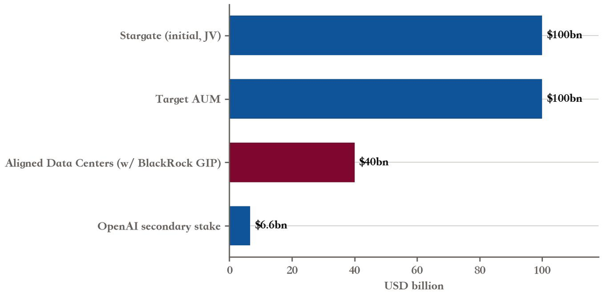

*Source: MGX and Mubadala disclosures; CNBC; Wamda; Funds Global MENA | Note: Target AUM and Stargate are programme-level figures; Aligned and the OpenAI stake are closed/secondary transactions.*

## 3.4 Qatar and the rest: QIA’s frontier bet, others selective

The Qatar Investment Authority took a different route, betting on the frontier-model layer directly rather than building infrastructure at home. It participated in Anthropic’s financing through the company’s $30 billion Series G at a $380 billion valuation, having first invested earlier in 2025 when the lab was valued at $183 billion, and joined a large raise for xAI (QIA 2025). These sit alongside earlier QIA technology bets in Stripe, Klarna, and SpaceX, marking a fund that prefers equity stakes in category leaders to hard-asset construction. The QIA has pledged about $500 billion of investment in the United States over the coming decade and signaled as many as 25 technology deals across 2025 and 2026, including a data-center venture with Blue Owl Capital to which it committed roughly $1 billion of equity (Bloomberg 2025).

The smaller funds are present but selective, which is itself informative about where conviction lies. The Kuwait Investment Authority deployed about $6 billion into AI and digitalization in 2025, and the Oman Investment Authority joined the xAI raise alongside Saudi Arabia’s Kingdom Holding, while Bahrain’s Mumtalakat has been comparatively quiet (Global SWF 2026). Across the region, Mubadala was the single most active GCC fund by transaction count in 2025, a reminder that Abu Dhabi, not Riyadh, has been the busiest dealmaker even as Saudi Arabia has built the most visible national champion. The pattern that emerges is a division of labor: Saudi Arabia building a domestic full-stack provider, Abu Dhabi financing global infrastructure and operating through G42, and Qatar buying equity in the frontier, with the smaller funds taking selective co-investment positions rather than leading.

# 4 Climbing the value chain: what they are buying

## 4.1 The ladder: energy at the bottom, applications at the top

The clearest way to read the Gulf’s purchases is as an attempt to climb the AI value chain, and the attempt succeeds at some layers and stalls at others. Figure 12 lays out the five layers, from energy and power at the base, through compute and data centers, chips, foundation models, and finally applications and services. The Gulf’s position differs sharply by layer, and the differences are the report’s central finding in visual form. It owns the bottom outright, where cheap gas, expanding solar, and abundant land are genuine comparative advantages. It is building the compute layer at scale and at speed. But the chip layer is access-only, gated by export rules examined in the next chapter, and the model layer is a set of minority stakes rather than holdings. The shape of the ladder is the shape of the argument: the Gulf owns the bottom and rents the top.

Figure 12: The Gulf owns the bottom of the AI stack and rents the top; the chip layer is the gated chokepoint

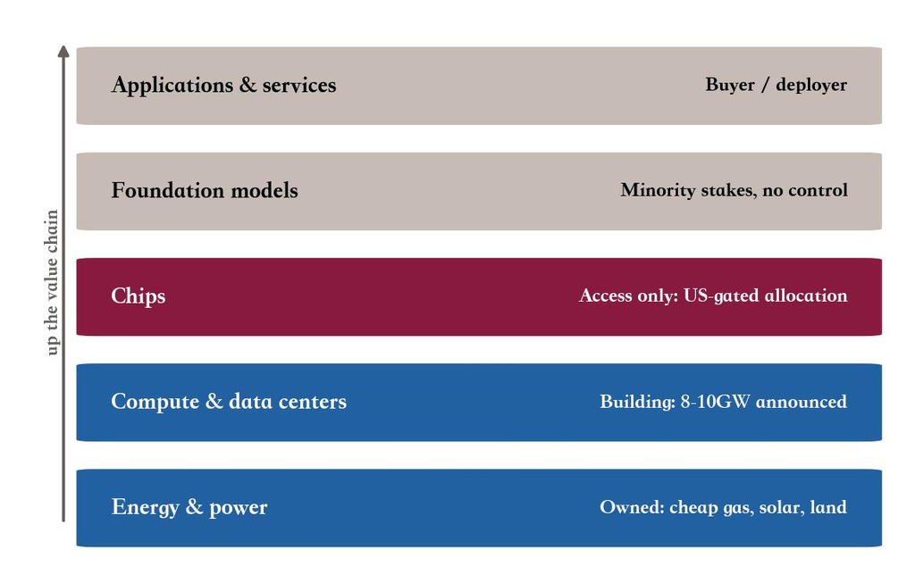

*Source: CSIS; Middle East Institute; Oxford Economics; author’s framework | Note: Blue = Gulf can own; claret = access gated by export policy; gray = minority/buyer position.*

The framing of compute as a strategic resource is increasingly explicit in the analytical literature, with one prominent treatment arguing that if compute is the new oil, control over it carries the strategic weight that hydrocarbons once did (CSIS 2025). For the Gulf the analogy is double-edged. It is well placed at the energy end, where it has historically held power, but the comparison breaks down precisely where it matters most: with oil, the Gulf controlled the resource; with compute, it controls the energy and the real estate but not the chips or the models. Understanding which rungs of the ladder are owned and which are rented is therefore the key to assessing the whole enterprise.

## 4.2 Energy and compute: turning cheap power into capacity

The Gulf’s first move up the chain is to convert its energy advantage into computing capacity, and the announced scale is genuinely large. Projects include a five-gigawatt campus in Abu Dhabi, spanning roughly ten square miles and described as the largest AI infrastructure project outside the United States, run by G42 with US hyperscalers; Humain’s decade ambition of roughly six gigawatts; and a 1.5-gigawatt NEOM project tied to a $5 billion DataVolt agreement (DataCenterDynamics 2025). Figure 13 ranks the projects. Energy is the real edge here: data centers are, in economic terms, machines for converting electricity into computation, and the Gulf can supply that electricity more cheaply than most regions, with land and capital to match.

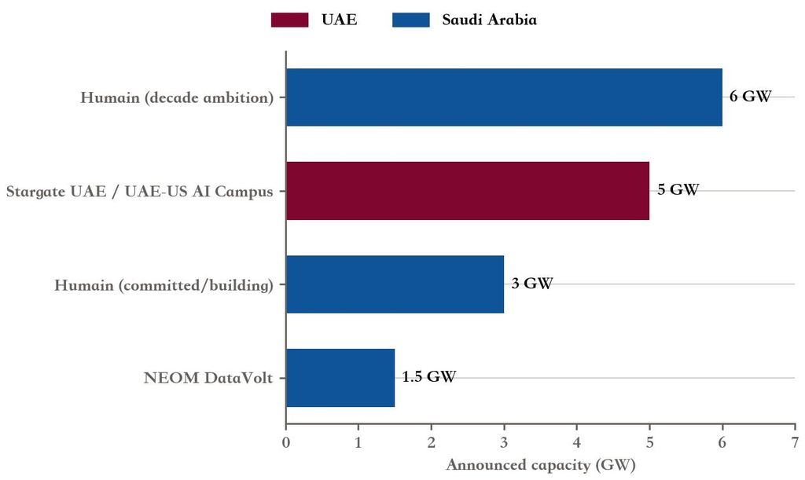

*Source: DataCenterDynamics; Introl; company announcements | Note: Figures are announced/ambition capacities, not yet built; Humain’s decade ambition overlaps its committed/building tranche.*

The gap between announcement and installation is the caveat that runs through this chapter, and it is large. The Gulf’s operational AI data-center capacity was on the order of one gigawatt in 2025, against announced and targeted pipelines of eight to ten gigawatts (Analysys Mason 2026). Figure 14 shows the gap. Analysys Mason expects accelerated GCC investment in AI data centers to reach $5 to $7 billion in 2026, a substantial figure but a fraction of what full delivery of the announced pipeline would require. Reading the announcements as installed capacity would overstate the build by close to an order of magnitude, which is why this report treats announced and operational capacity as distinct calipers throughout.

Figure 14: A wide gap separates operational capacity (~1GW) from the 8-10GW the Gulf has announced

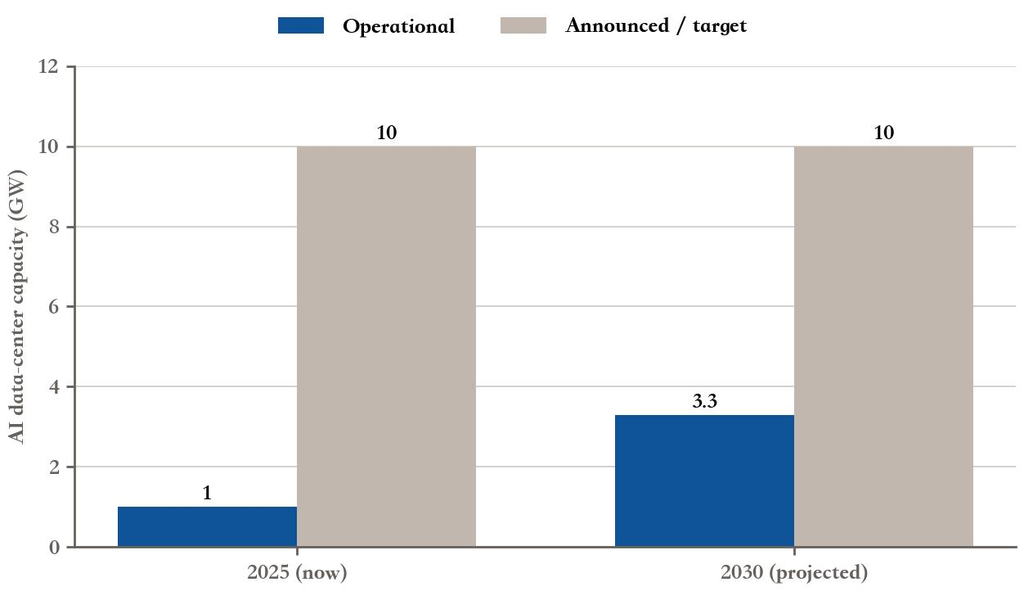

*Source: Analysys Mason; Introl; company announcements (Stargate UAE, Humain, NEOM) | Note: Announced/target figure is the upper end of disclosed project pipelines; operational figure is installed capacity.*

The build also runs into physical limits that the headline gigawatt figures obscure. Large AI campuses are intensely thirsty for both power and water, and the Gulf is among the most water-stressed regions on earth, which has pushed operators toward closed-loop cooling and solar power but also raised questions about the sustainability of multi-gigawatt clusters in a desert climate. The energy advantage is real, but it is not unlimited, and the cost of delivering reliable power and cooling at the announced scale is one of the variables that will determine whether the projects are completed as planned or quietly trimmed.

## 4.3 Chips: buying allocation, not yet fabrication

The compute build runs on chips the Gulf cannot make, and here the funds have bought access rather than supply. The UAE secured a framework for up to 500,000 of Nvidia’s most advanced chips a year from 2025 through 2027, an allocation worth roughly $15 billion, while Humain’s first tranche was 18,000 units with more to follow (CNBC 2025c; NVIDIA 2025). Figure 15 contrasts the two volumes. The scale difference between the UAE’s annual allocation and Humain’s opening tranche is real, but it is less important than what the two have in common: both are allocations of foreign-made silicon, granted under terms set abroad, not domestic fabrication.

Figure 15: The UAE’s annual Nvidia allocation dwarfs Humain’s first chip tranche, but both are access, not supply

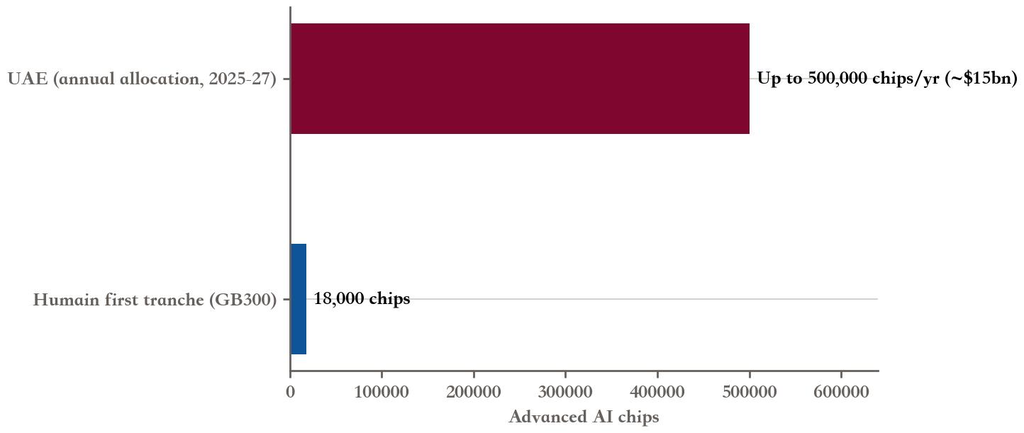

*Source: Nvidia newsroom; CNBC; Axios | Note: UAE up to 500,000 advanced Nvidia chips/yr 2025-27 (~$15bn); Humain first tranche 18,000 GB300, with more to follow; neither is domestic fabrication.*

This is the rung where ownership ends and dependence begins. Designing or manufacturing leading-edge AI accelerators requires a supply chain, from design tools to fabrication, that no Gulf state possesses and that takes many years and tens of billions of dollars to build, even with capital in hand. The Gulf has bought a seat at the compute table, and a generous one, but it has not bought the factory, and on current evidence it has no near-term path to doing so. The chip layer is therefore the point at which the value-chain ascent stops being a question of capital, which the Gulf has, and becomes a question of access, which it must negotiate. That negotiation is the subject of the next chapter.

## 4.4 Models and applications: minority stakes in the frontier

At the top of the chain, the Gulf is an investor rather than a builder, and the distinction is decisive. GCC funds hold stakes across the leading Western AI labs, but none controls one. Figure 16 maps the participations: MGX in OpenAI and xAI, the QIA in Anthropic and xAI, and Saudi and Omani vehicles in xAI (QIA 2025; CNBC 2025a). These are minority positions taken at the valuations of the 2025 funding rounds, which were extraordinary by any historical standard: OpenAI at $500 billion, Anthropic at $380 billion, and xAI at $200 billion (Bloomberg 2025). Figure 17 shows the headline valuations.

Figure 16: GCC funds hold minority stakes across all three Western frontier labs, but control none

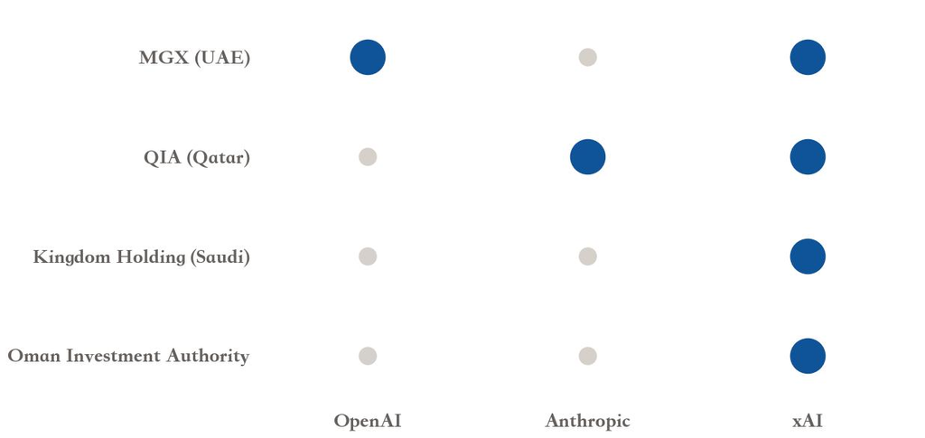

*Source: QIA newsroom (Anthropic); company disclosures; Bloomberg; press | Note: Filled dot = disclosed stake or funding-round participation; stakes are minority and non-controlling.*

Buying into the frontier at these levels is two bets at once. The first is financial: that the model layer will compound in value faster than the prices paid, which at half-a-trillion-dollar valuations requires extraordinary future growth to justify. The second is strategic: that minority stakes buy relationships, with the labs whose models will run on Gulf compute, and a window onto the frontier, more than they buy control or technology transfer. The relationship dimension may matter more than the equity. A fund that has invested in OpenAI and built data centers with Oracle and Nvidia is woven into the same ecosystem, which can help secure chips, models, and talent. But a minority stake in a US-headquartered lab is exposure to the frontier, not ownership of it, and it does not move the Gulf up the rung from renter to builder. That limitation sets up the binding constraint examined next.

Figure 17: GCC funds bought into the frontier at peak valuations: OpenAI $500bn, Anthropic $380bn, xAI $200bn

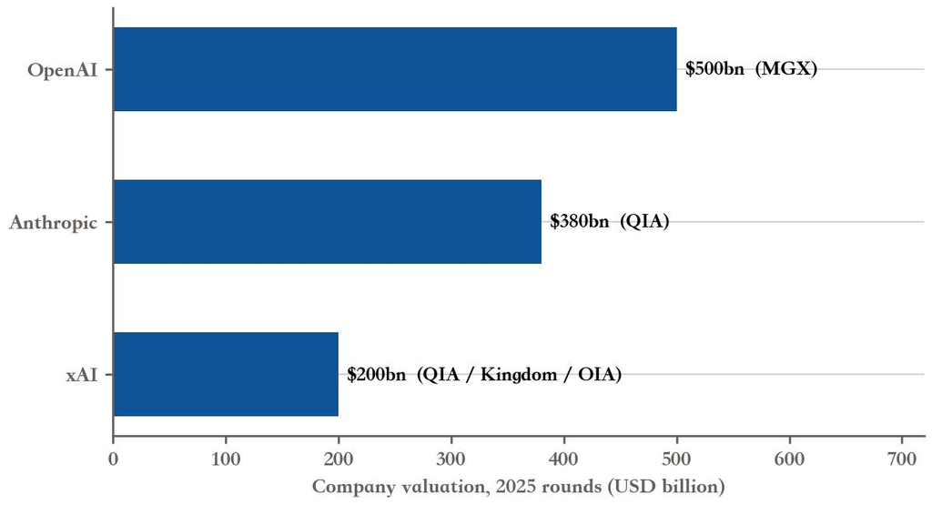

*Source: QIA newsroom (Anthropic Series G); Bloomberg; Anthropic; press | Note: Valuations are the headline figures from 2025 rounds in which the named GCC investor participated.*

# 5 The binding constraint: chip access and the regulatory ceiling

## 5.1 Compute access is set outside the region

Figure 18: US chip-export rules shifted repeatedly in 2025; access is the one variable the Gulf cannot set itself

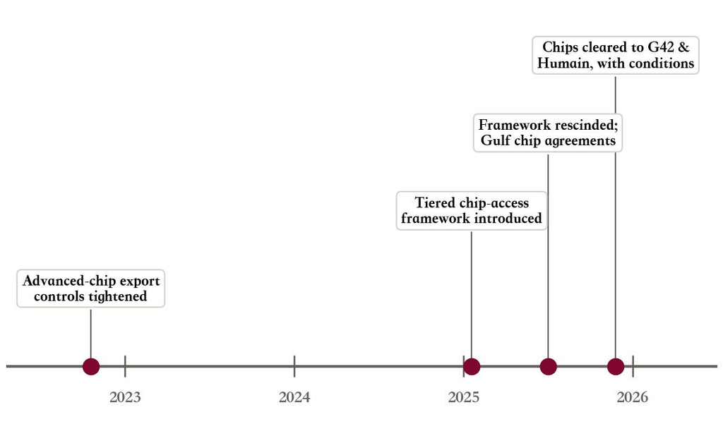

*Source: Carnegie Endowment; CSIS; CNBC (export-policy reporting) | Note: Selected regulatory milestones; the 2025 changes opened, then conditioned, advanced-chip access for Gulf AI operators.*

The volatility itself is a risk distinct from the direction of policy. A capacity build planned over a decade depends on chip deliveries scheduled over years, and a regulatory regime that can tighten or loosen within months injects uncertainty into every project finance model. Even favorable rules, if they can be revised, raise the cost of capital for projects that assume continued access. This is why analysts assessing the Gulf chip agreements have stressed that the value of the deals depends not only on the volumes granted but on the durability and conditionality of the access (Carnegie Endowment 2025).

## 5.2 The price of access: the conditions attached to advanced chips

Access came as a bargain, and the terms are as important as the volumes. In exchange for advanced compute, hyperscaler cloud partnerships, and a recognized role as a global AI-infrastructure hub, the Gulf accepted a set of conditions: security and reporting requirements, approved-operator and data-control rules, supply-chain alignment with US vendors, and allocations that are capped and renewable on an annual basis (Carnegie Endowment 2025; CSIS 2025). Figure 19 sets the gains against the conditions. The framing here is deliberately practical rather than political: the fact that matters for an investor is that the chip layer is available on terms defined elsewhere, which is precisely what caps compute sovereignty.

Figure 19: Advanced-chip access came as a bargain: capability in exchange for conditions

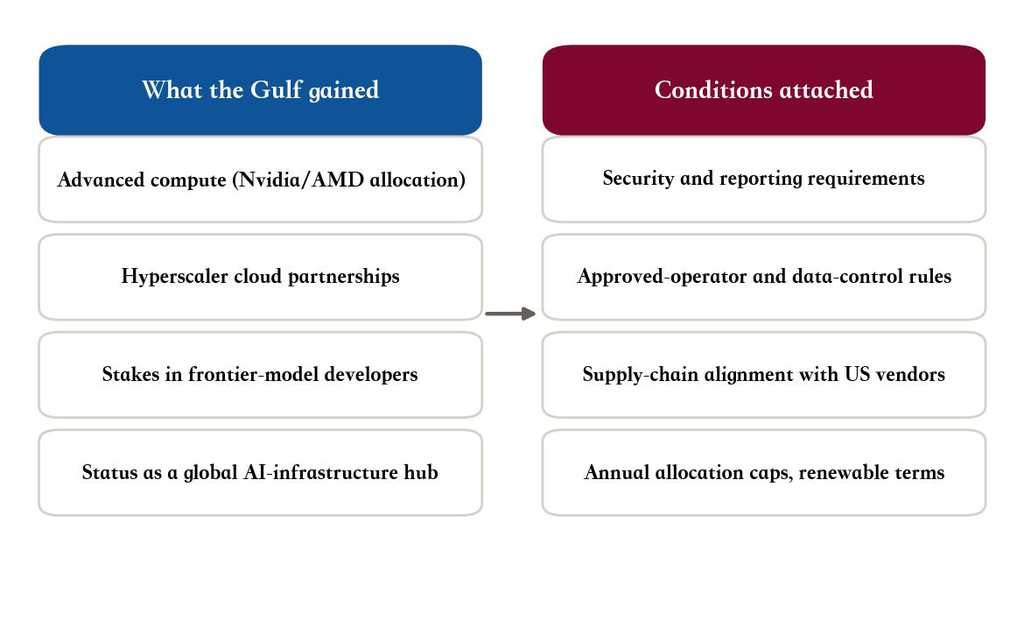

*Source: Carnegie Endowment; CSIS; Atlantic Council; export-policy reporting | Note: Schematic; access to the chip layer is granted under terms set outside the region, which is what caps compute sovereignty.*

The conditions reshape the risk profile of the entire build. A data-center business running on annually renewable foreign allocations, with approved-operator rules and reporting obligations, is a different asset from one built on owned or domestically secured supply. Its continuity depends on maintaining the conditions, which include alignment with the vendor ecosystem that supplies the chips. For Gulf operators that had built technology relationships across multiple regions, meeting these conditions has meant reorienting toward the US vendor stack, with G42 the most visible example of a Gulf operator restructuring its partnerships as the price of admission to advanced compute. None of this is unusual in regulated high-technology trade, but it is the concrete mechanism by which the chip layer remains, for now, a rented rung rather than an owned one.

## 5.3 The sovereignty ceiling: owning infrastructure, renting the frontier

The frontier-model layer sits even further beyond reach than the chips. The leading foundation models are overwhelmingly built outside the Gulf: by one widely cited count, the United States produced about 40 large foundation models in 2025, China about 15, and the European Union about 3 (Atlantic Council 2025; Middle East Institute 2025). No GCC-headquartered lab is among the leaders. Figure 20 shows the distribution. The Gulf participates in this layer as an investor and a host, providing capital and compute, but not as a builder of frontier models, and building one is not principally a question of money. It requires concentrations of specialized talent, accumulated research, and iterative scale that capital alone has so far not been able to buy quickly.

Figure 20: The frontier-model layer sits outside the Gulf: the US produced ~40 models to China’s ~15 and the EU’s ~3

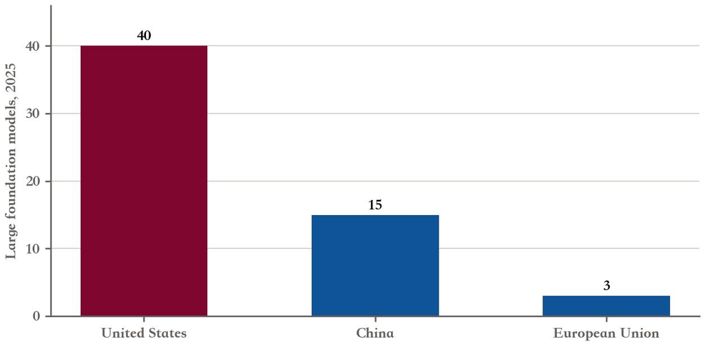

*Source: Atlantic Council; Stanford AI Index-style counts (approximate) | Note: No GCC-headquartered lab is among the leading foundation-model developers; the Gulf participates as investor and host, not builder.*

Combining the chip constraint with the model constraint produces the report’s central structural finding, which can be stated precisely. The Gulf can own energy and compute, the two lower rungs, where its comparative advantages are real. It can buy minority exposure to chips and models, the two upper rungs, through allocations and equity stakes. But it cannot, on current evidence, own the two layers, advanced silicon and frontier models, that confer genuine technological autonomy. That is the sovereignty ceiling. It does not make the strategy unwise; hosting the world’s compute and financing its frontier may be a perfectly good business. But it does mean the Gulf’s AI position is one of integration into a US-anchored stack rather than independence from it, and that integration is the standing condition of the whole enterprise.

# 6 Does the bet pay? The returns and sustainability verdict

## 6.1 The bull case: option value on the technology of the era

The strongest argument for the pivot is that AI is too important to sit out, and that the Gulf brings genuine advantages to it. PwC estimates that AI could add about $320 billion to the Middle East economy by 2030, equivalent to 11 percent of regional GDP, with Saudi Arabia gaining $135 billion, or 12.4 percent of its GDP, and the UAE $96 billion, or 13.6 percent (PwC 2025). Figure 21 shows the distribution; Saudi Arabia and the UAE together capture more than 70 percent of the projected regional total. McKinsey similarly estimates that generative AI could add $21 to $35 billion a year to GCC economies, on top of the larger gains from traditional sources, and notes that GCC organizations have adopted AI tools at rates above the global average (McKinsey 2025).

Figure 21: The bull case: AI could add $320bn to the Middle East by 2030, led by Saudi Arabia and the UAE

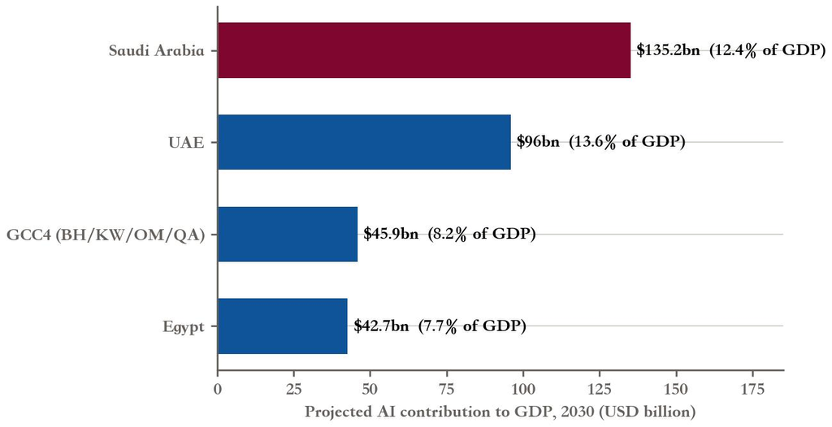

*Source: PwC, The Potential Impact of AI in the Middle East | Note: PwC scenario estimate; Saudi $135bn (12.4% of GDP) and UAE $96bn (13.6%) together account for over 70% of the regional total.*

These projections should be read as scenario estimates rather than forecasts, but the Gulf’s specific advantages behind them are concrete. It has cheap energy and land for data centers, deep pools of patient capital that can absorb long payback periods without redemption pressure, and, since 2025, negotiated access to advanced chips and partnerships with the leading labs and hyperscalers. For a region seeking to diversify away from oil, AI infrastructure offers something earlier diversification bets such as tourism or domestic manufacturing did not: a globally tradable service, compute, that can earn foreign revenue from customers outside the region. On this reading, the pivot is the rational deployment of a genuine comparative advantage into the defining growth sector of the era, and the option value of a seat at the table is worth the price even if individual projects disappoint.

## 6.2 The bear case: circular financing and uncertain returns

The case against is financial, and it begins with how the AI build is funded. Much of the global build-out is financed through a web of interlinked deals in which the same capital recirculates as chips, cloud commitments, and equity, a pattern observers have compared to the vendor financing of the late-1990s technology boom (Bloomberg 2026). Figure 22 sketches the web and the Gulf’s place in it. Gulf capital is wired into these flows through stakes in OpenAI, joint ventures with Oracle on Stargate, and chip purchases from Nvidia, which means it is exposed to the same circularity: if AI revenue across the ecosystem disappoints, losses can cascade through interlinked balance sheets rather than staying contained to a single project.

Figure 22: Gulf capital is wired into AI’s circular-financing web, where the same dollars recirculate as chips, cloud and equity

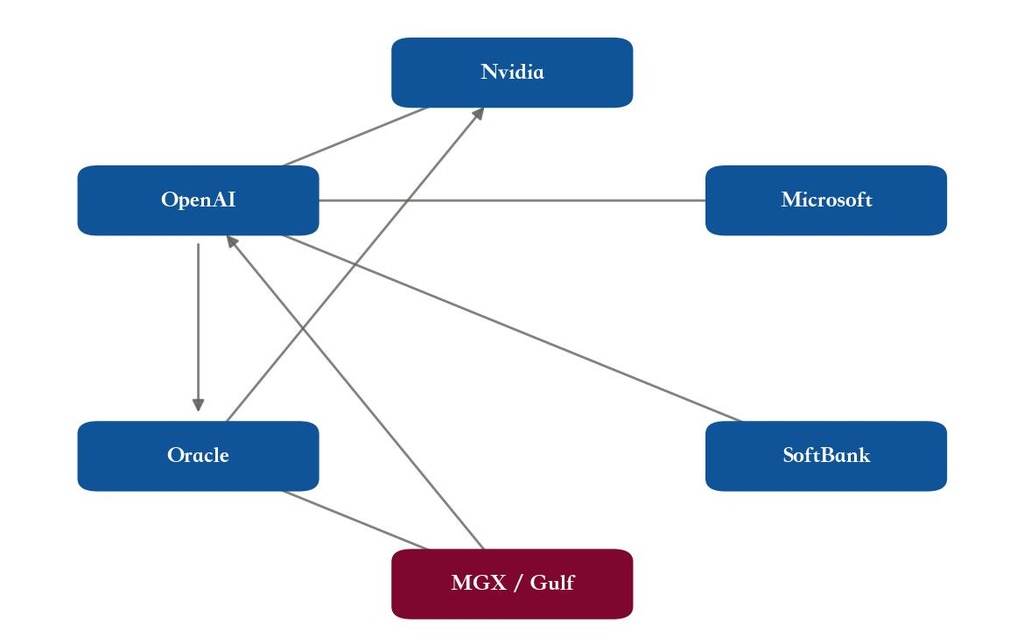

*Source: Bloomberg (AI Circular Deals); company disclosures; author’s mapping | Note: Schematic of major flows, not exhaustive; circularity raises cascading-loss risk if AI revenue disappoints.*

The returns themselves remain unproven. The funds disclose no segment-level returns on their AI investments, so any claim about profitability is inference rather than measurement. The underlying economics of data centers are uncertain: capacity is being built well ahead of demonstrated demand, and analysts have flagged the risk of underutilization and thin margins if the build outruns usage (Gulf International Forum 2025). The frontier labs into which the Gulf has bought are, for the most part, still loss-making, promising future profits against present cash burn. The IMF warned in 2026 that regional risks could slow AI investment as financial vulnerabilities rise, and reporting through early 2026 began testing the Gulf’s data-center ambitions against exactly these pressures (Semafor 2026). None of this proves the bet will fail. It does mean the bet rests on expected future cash flows that do not yet exist, which is the definition of an option rather than an income stream, and options can expire worthless.

## 6.3 Concentration and fiscal exposure: the bet rides on oil and a few names

The bet is also concentrated, which amplifies both the upside and the downside. A handful of mega-deals account for a large share of the capital at risk: the PIF’s $55 billion buyout of Electronic Arts, MGX’s $40 billion Aligned acquisition, and a cluster of multi-billion-dollar infrastructure agreements including Humain’s AWS and AirTrunk deals and NEOM’s DataVolt project (CNBC 2025a). Figure 23 ranks the largest disclosed transactions. Concentration cuts both ways. It gives the Gulf real, controlling or anchor positions in marquee assets, which is part of the strategic appeal, but it ties outcomes to a small number of names and sectors, so a stumble in one or two could weigh heavily on the whole programme.

Figure 23: Capital concentrates in a handful of mega-deals, led by EA ($55bn) and Aligned ($40bn)

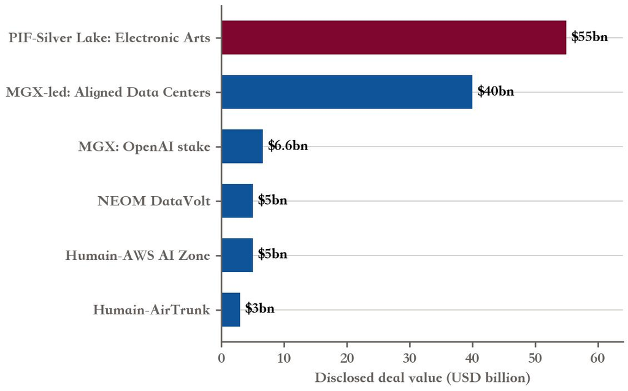

*Source: Company disclosures; Bloomberg; CNBC; press | Note: EA is a gaming buyout (PIF/Silver Lake) included as a top sovereign-tech transaction; the others are AI-infrastructure deals.*

It is essential to separate announced intent from deployed capital, because the gap between the two is where much of the pivot’s apparent scale lives. The headline pledges from the 2025 round of US-Gulf agreements were very large, on the order of $600 billion linked to Saudi Arabia, $243 billion to Qatar, and $200 billion to the UAE, but these are multi-year, multi-sector commitments, not deployed AI capital (Rest of World 2025). Figure 24 shows the headline figures, which should be read as a ceiling on ambition rather than a measure of money spent. Realized deployment to date is a small fraction of the pledged total, and treating the two as equivalent, as much coverage implicitly does, materially overstates the pivot. The disciplined figures are the ones earlier in this report, the $66 billion of single-year sovereign AI deployment and the specific closed deals, not the trillion-dollar pledge headlines.

Figure 24: The headline $1.0tn in Gulf pledges is announced intent, not deployed capital

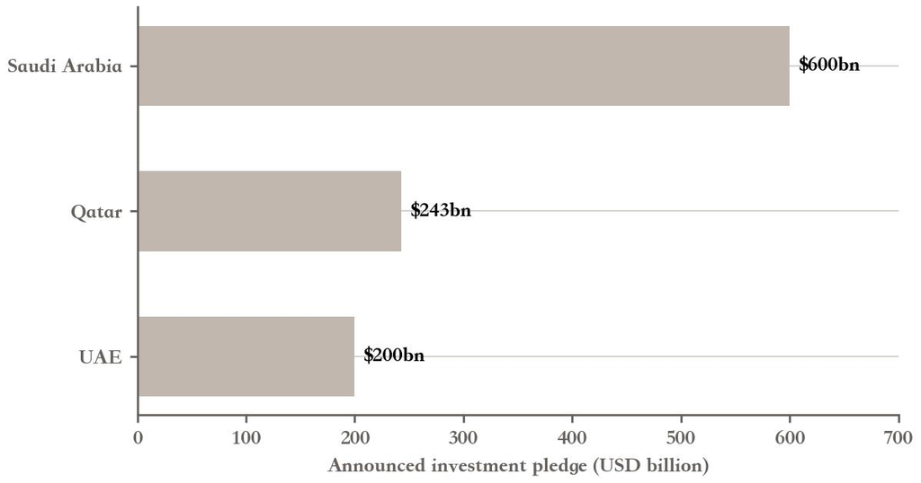

*Source: Axios; Reuters; Euronews; Rest of World (May 2025 US-Gulf agreements) | Note: Announced pledges spanning multiple years and sectors, not committed or deployed AI capital; realized deployment is a small fraction to date.*

Beneath the deal concentration sits the fiscal exposure established in the second chapter. The funding base remains oil-sensitive, and the IMF’s stress scenario, in which a negative oil shock pushes the Saudi deficit past 10 percent of GDP, would tighten exactly the budgets that finance the AI build (IMF 2025). The bet, in other words, is doubly geared: to the success of AI assets whose returns are unproven, and to an oil price that the funders do not control. That combination is what makes the verdict conditional rather than clean.

## 6.4 The verdict: defensible as strategy, unproven as investment

Weighing the two cases, the pivot is best understood as a strategic option rather than a conventional investment, and the distinction is not semantic. As strategy and diversification, it is defensible: the Gulf is deploying a genuine comparative advantage, cheap energy and patient capital, into the most important technology of the era, on terms that give it real assets, foreign revenue potential, and relationships across the global AI ecosystem. A sovereign investor with a multi-decade horizon and a need to build a post-oil economy has a stronger case for paying the option premium than a private fund chasing near-term returns would.

As an investment judged on risk-adjusted returns, however, it is unproven. The cash flows do not yet exist, the financing is circular, the capital is concentrated in a few names, and the funding base is oil-sensitive. This is a directional judgment, offered as such, not a measured return, because the data to measure returns is not disclosed. The honest conclusion is that the pivot buys the Gulf a position in the AI economy at a defensible strategic price, while leaving open the question of whether that position will earn its cost of capital. Which of those two readings, strategic success or financial disappointment, prevails depends on the variables set out in the final chapter.

# 7 Conclusion and outlook

## 7.1 A sovereign AI machine with a gated ceiling

In roughly 24 months the Gulf built a coordinated, vertically integrated sovereign AI-capital machine. It stood up national champions, contracted gigawatts of compute, negotiated chip access, and bought into the frontier labs, deploying more sovereign capital into AI than any other region. The achievement is real, and it reflects advantages, cheap energy, patient capital, and decisive state direction, that few other regions can match. So is its limit. The machine owns the bottom of the value chain and rents the top; its access to the decisive chip and model layers is granted on terms set outside the region; and its financial payoff rests on returns that have not yet materialized, against a softer oil outlook that is tightening the very budgets funding the build. The Gulf has bought itself a seat in the AI economy. It has not yet bought autonomy within it, and it has not yet proven the seat will pay.

That dual conclusion, real achievement and gated ceiling, is the honest summary. It resists both the boosterism that reads the pledges as deployed trillions and the dismissal that treats the whole effort as a bubble-era vanity project. The Gulf has made a serious, well-resourced, and coherent bet on becoming an indispensable node in the global AI infrastructure. Whether that bet compounds into a post-oil pillar of the economy or settles into an expensive option that never quite pays is not yet decidable from the evidence, and claiming otherwise in either direction would overstate what the data supports.

## 7.2 What to watch from 2026: five variables

Whether the bet pays will become visible in five variables over the coming years. Figure 25 sets them out. The first two are largely outside Gulf control: the stability of chip-export rules, which a single regulatory cycle can tighten, and the oil price relative to fiscal breakeven, which determines how much room the funders have. The next three are partly within it: whether the announced data-center capacity gets built and used at healthy margins rather than sitting idle, whether minority stakes in the frontier labs translate into genuine capability and not just financial exposure, and how concentrated the funds allow themselves to become in a few mega-deals and names.

Figure 25: Five variables will decide whether the Gulf’s AI bet pays off

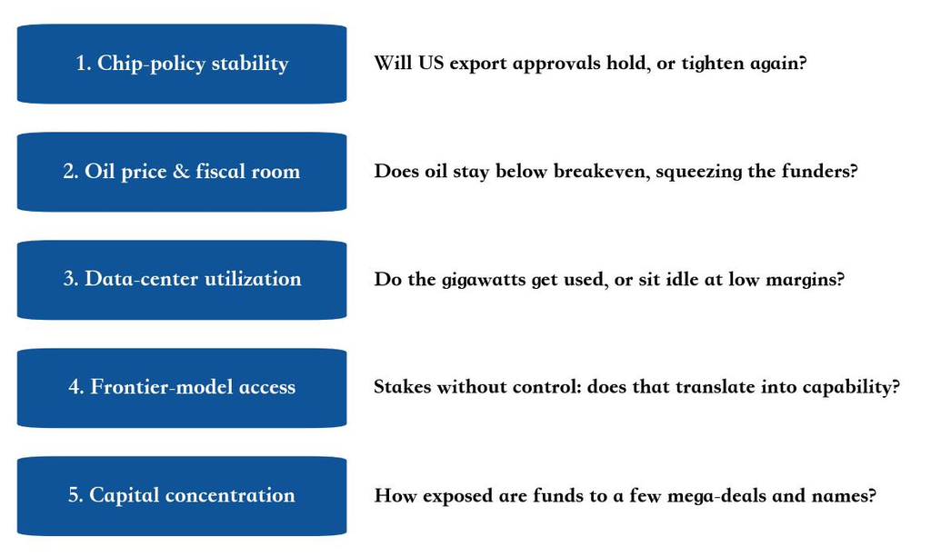

*Source: Author’s synthesis; Semafor; IMF | Note: A monitoring frame for 2026 onward; the first two are largely outside Gulf control, the last three partly within it.*

The interaction of the two external variables defines the payoff envelope, and it is worth holding in mind as a single picture. Figure 26 sketches it as a matrix of chip access against oil price. With open chip access and firm oil, the Gulf can fund its ascent from its own resources, the full-throttle case. With open chips but soft oil, the build continues but leans increasingly on debt, a borrowed ascent. With restricted chips, capital cannot buy the compute it needs regardless of the oil price, leaving cash without compute. And the downside case, restricted chips and soft oil together, would stall the bet. The Gulf sets neither variable.

Figure 26: Whether the bet pays turns on two variables the Gulf only partly controls: chip access and oil

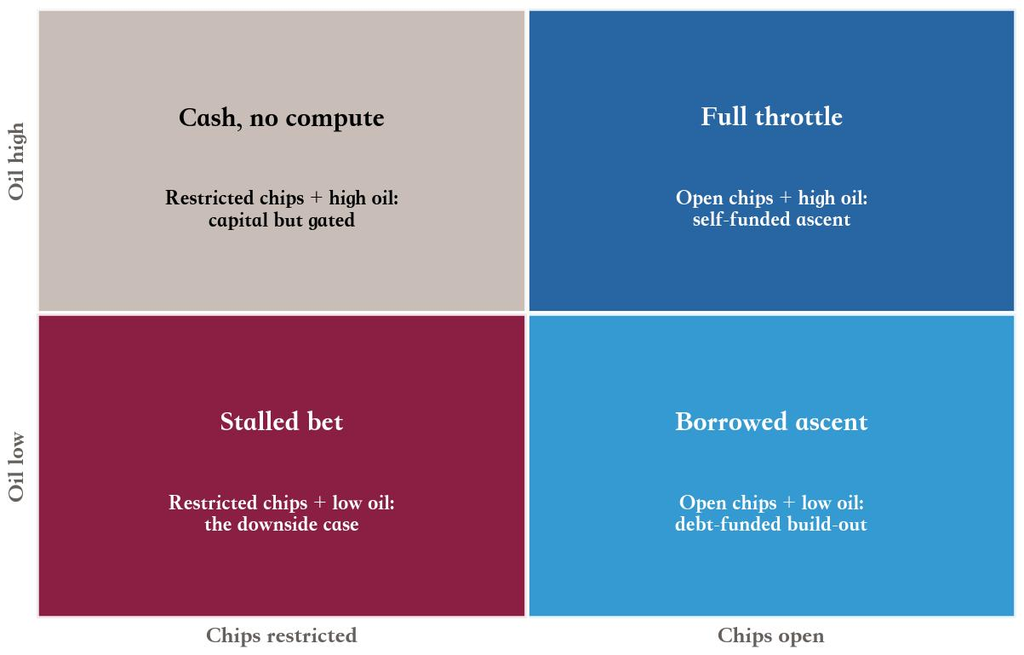

*Source: Author’s framework | Note: Schematic scenario matrix; the Gulf sets neither US export policy nor the oil price, both of which define the payoff envelope.*

That, finally, is the report’s central point. The Gulf has moved with remarkable speed and scale to build a sovereign AI machine, marshaling more than $3 trillion of capital and a coordinated institutional stack behind a coherent strategy. Yet the two factors that will most determine its return, advanced-chip access and the oil price, are the two it controls the least. The pivot has secured the Gulf a place in the AI economy. Earning a return on that place is a separate question, and its answer lies partly in the hands of others.

# 8 References

Analysys Mason. 2026. *Accelerated Investment in AI Data Centres in the GCC Will Reach USD5-7 Billion in 2026*. Analysys Mason. https://www.analysysmason.com/about-us/news/predictions-2026/prediction-ai-investment-gcc/.

Atlantic Council. 2025. *AI Geopolitics and the Global Foundation-Model Landscape*. Atlantic Council. https://www.atlanticcouncil.org/programs/geotech-center/.

Bloomberg. 2025. *AI Investments: Blue Owl, xAI Deals Solidify QIA’s $500 Billion US Pledge*. Bloomberg. https://www.bloomberg.com/news/articles/2025-09-29/ai-investments-blue-owl-xai-deals-solidify-qia-s-500-billion-us-pledge.

Bloomberg. 2026. *AI Circular Deals: How Microsoft, OpenAI and Nvidia Keep Paying Each Other*. Bloomberg. https://www.bloomberg.com/graphics/2026-ai-circular-deals/.

Carnegie Endowment. 2025. *How to Gauge Whether the AI Chip Deals with Gulf Countries Are Any Good*. Carnegie Endowment for International Peace. https://carnegieendowment.org/emissary/2025/05/ai-chip-trump-gulf-uae-saudi-security-risk-good-deal.

CNBC. 2025a. *Abu Dhabi’s MGX Investments in OpenAI, TikTok and Crypto*. CNBC. https://www.cnbc.com/2025/10/15/abu-dhabis-mgx-investments-in-trump-crypto-tiktok-openai-.html.

CNBC. 2025b. *Saudi AI Firm Humain Is Pouring Billions into Data Centers. Will It Pay Off?* CNBC. https://www.cnbc.com/2025/08/27/saudi-arabia-wants-to-be-worlds-third-largest-ai-provider-humain.html.

CNBC. 2025c. *US Approves AI Chip Exports to Gulf Tech Giants*. CNBC. https://www.cnbc.com/2025/11/20/us-approves-ai-chip-exports-to-gulf-after-saudi-crown-prince-visit.html.

CSIS. 2025. *If Compute Is the New Oil, War in the Gulf Significantly Raises the Stakes*. Center for Strategic and International Studies. https://www.csis.org/analysis/if-compute-new-oil-war-gulf-significantly-raises-stakes.

DataCenterDynamics. 2025. *US and UAE Plan to Build 5GW AI Data Center Campus, Run by G42 and US Hyperscalers*. DataCenterDynamics. https://www.datacenterdynamics.com/en/news/us-and-uae-plan-to-build-5gw-ai-data-center-campus-run-by-g42-and-american-hyperscalers/.

DataCenterDynamics. 2026. *Humain and Infra Set up $1.2bn Financing Package for 250MW of Data Center Space*. DataCenterDynamics. https://www.datacenterdynamics.com/en/news/.

Emirates NBD Research. 2025. *GCC: Lower Oil Price Will Weigh on Budgets*. Emirates NBD Research. https://www.emiratesnbdresearch.com/en/articles/gcc-lower-oil-price-will-weigh-on-budgets.

Global SWF. 2025. *Sovereign Wealth Fund Rankings (July 2025)*. Global SWF; reported via Gulf Business and Zawya. https://globalswf.com/ranking.

Global SWF. 2026. *2026 Annual Report: Sovereign Wealth and Public Pension Funds*. Global SWF. https://globalswf.com/reports.

Gulf International Forum. 2025. *Gulf AI Infrastructure: Examining the Business and Economic Case*. Gulf International Forum. https://gulfif.org/gulf-ai-infrastructure-examining-the-business-and-economic-case/.

IMF. 2025. *Saudi Arabia: 2025 Article IV Consultation, Staff Report (Country Report No. 25/223)*. International Monetary Fund. https://www.imf.org/-/media/files/publications/cr/2025/english/1sauea2025001-source-pdf.pdf.

McKinsey. 2025. *Generative AI in the GCC: Economic Potential*. McKinsey & Company. https://www.mckinsey.com/.

MGX. 2025. *MGX Fund Management: Mandate and Partnerships*. MGX; company disclosures. https://mgx.ae/.

Middle East Institute. 2025. *AI, the Gulf, and the US: A Primer*. Middle East Institute. https://mei.edu/report/ai-the-gulf-and-the-us-a-primer/.

NVIDIA. 2025. *HUMAIN and NVIDIA Announce Strategic Partnership to Build AI Factories in Saudi Arabia*. NVIDIA Newsroom. https://nvidianews.nvidia.com/news/humain-and-nvidia-announce-strategic-partnership-to-build-ai-factories-of-the-future-in-saudi-arabia.

PwC. 2025. *The Potential Impact of AI in the Middle East*. PwC Middle East. https://www.pwc.com/m1/en/publications/potential-impact-artificial-intelligence-middle-east.html.

QIA. 2025. *QIA Increases Investment in Anthropic Through $30 Billion Series g Financing*. Qatar Investment Authority Newsroom. https://www.qia.qa/en/Newsroom/Pages/default.aspx.

Rest of World. 2025. *Middle East Trip Sparks $2.2T in Tech and Chip Deals*. Rest of World. https://restofworld.org/2025/trump-middle-east-trip-ai-chip-tech-deals/.

Semafor. 2025. *PIF’s AI Unit HUMAIN Has Already Sold Out Its Data Center Capacity*. Semafor. https://www.semafor.com/article/08/27/2025/pifs-ai-unit-has-already-sold-out-its-data-center-capacity.

Semafor. 2026. *Data Centers Under Fire Test Gulf Sovereign AI Ambitions*. Semafor. https://www.semafor.com/article/04/13/2026/data-centers-under-fire-test-gulf-sovereign-ai-ambitions.

The National. 2025. *Saudi’s PIF Raises 2030 Assets Target to $2.67 Trillion After Exceeding Last Year’s Goal*. The National. https://www.thenationalnews.com/business/2025/04/27/saudis-pif-raises-2030-target-to-267-trillion-after-exceeding-last-years-goal/.